# Data Management

Alan T. Arnholt

Spring 2015

Start by loading your data set. The URL is broken up into two parts so that the R code will fit on the page. The function `paste0()` is used to concatenate two strings.

```r
firstpart <- "http://www1.appstate.edu/~arnholta/classes/"
secondpart <- "PDS/DATAandCODEBOOKS/NESARC/NESARC_pds.RData"
site <-paste0(firstpart, secondpart)
con <- url(site)
load(con)
NESARC[1:6, 1:10] # show first six rows and first 10 columns
```

```
  IDNUM ETOTLCA2 ETHRACE2A   PSU STRATUM   WEIGHT CDAY CMON CYEAR REGION
1     1       NA         5  4007     403 3928.614   14    8  2001      4
2     2   0.0014         5  6045     604 3638.692   12    1  2002      4
3     3       NA         5 12042    1218 5779.032   23   11  2001      3
4     4       NA         5 17099    1704 1071.754    9    9  2001      2
5     5       NA         2 17099    1704 4986.952   18   10  2001      2
6     6   0.0021         2 17099    1704 2596.887    7    9  2001      2
```

```r
rm(NESARC) # removing NESARC
```

Creating a connection, loading the connection, and knowing the actual name of the data set is a little too much! So, I wrote an `R` package (`PDS`) that has the four data sets from *Passion Driven Statistics* that should make accessing the data a little easier. You may download the most recent version of `PDS` using the devtools function `install_github()` to install `PDS` in `R`.

However, you need to make sure you’re set up to develop packages. This is platform specific:

- On Windows, download and install [Rtools](http://http://cran.r-project.org/bin/windows/Rtools/).
- On the Mac, make sure you have [Xcode](https://developer.apple.com/xcode/) installed.
- On Linux, make sure you have the R-dev packages installed.

You can check everything is installed correctly with the `has_devel()` function from the `devtools` package. Type the following at the `R` prompt:

```r
install.packages("devtools", dependencies = TRUE)
devtools::has_devel()
```

If everything is installed correctly, the function will print some output and then return **TRUE**.

To install the `PDS` package, type the following at the `R` prompt:

```r
devtools::install_github('alanarnholt/PDS')
```

Once the `PDS` package is installed, you will need to load the package using the `library` function.

```r
library(PDS)
```

Now it is possible to access the data in the four data sets by typing the name of the data frame at the `R` prompt. For example, to see the first five values in the variable `incomeperperson` from the `gapminder` data frame enter

```r
gapminder[1:5, 'incomeperperson']
```

```
[1]        NA  1914.997  2231.993 21943.340  1381.004
```

### Using the `dplyr` package

The package `dplyr` must first be installed before it can be used. There are two ways one can install the package. The easiest way to install `dplyr`, is to type

```r
install.packages("dplyr")
```

at the `R` prompt. If you want the latest version of `dplyr`, you can install the development version from GitHub provided you have the required tools to build `R` packages installed on your machine (`Rtools` for Windows users, `XCode` for Mac users, etc.).

```r
if (packageVersion("devtools") < 1.6) {
  install.packages("devtools")
}
devtools::install_github("hadley/lazyeval")
devtools::install_github("hadley/dplyr")
```

### Renaming Variables

Renaming the variables `IDNUM`, `ETOTLCA2`, and `ETHRACE2A` to `UniqueID`, `EthanolConsumption`, and `Ethnicity` is done with the `rename` function. Although it is not a requirement, the data frame `NESARC` is converted to a `data frame tbl` per the advice given in the `dplyr` vignette. The `rename` function takes a data frame or data frame tbl as its first argument while the syntax `new_name = old_name` is used as the second argument.

```r
library(dplyr)
# Create a data frame tbl see ?tbl_df
NESARCtbl <- tbl_df(NESARC)
NESARC <- rename(NESARCtbl, UniqueID = IDNUM, EthanolConsumption = ETOTLCA2,
                 Ethnicity = ETHRACE2A)
NESARC[1:5, 1:5]
```

```
Source: local data frame [5 x 5]

  UniqueID EthanolConsumption Ethnicity   PSU STRATUM
1        1                 NA         5  4007     403
2        2             0.0014         5  6045     604
3        3                 NA         5 12042    1218
4        4                 NA         5 17099    1704
5        5                 NA         2 17099    1704
```

### Coding missing values

Note that the variable `S3AQ3B1` uses a 9 to record `unknown` for smoking frequency.

```r
NESARC$S3AQ3B1[NESARC$S3AQ3B1 == 9] <- NA
summary(NESARC$S3AQ3B1)  # Note that 9 still appears
```

```
    1     2     3     4     5     6     9  NA's
14836   460   687   747   409   772     0 25182
```

```r
NESARC$S3AQ3B1 <- factor(NESARC$S3AQ3B1)[, drop = TRUE]
summary(NESARC$S3AQ3B1)  # Unused level no longer appears
```

```
    1     2     3     4     5     6  NA's
14836   460   687   747   409   772 25182
```

I hate to look back at the code book to figure out what the heck the numbers represent in this case! One of the great things about the `R` language is how it handles a wide variety of data types. In this case, the variable `S3AQ3B1` is a factor with numeric labels for the levels of the factor. To change the numeric labels to text type the following:

```r
NESARC$S3AQ3B1 <- factor(NESARC$S3AQ3B1,
                         labels = c("Every Day", "5 to 6 Days/week",
                                    "3 to 4 Days/week", "1 to 2 Days/week",
                                    "2 to 3 Days/month", "Once a month or less"))
summary(NESARC$S3AQ3B1)
```

```
           Every Day     5 to 6 Days/week     3 to 4 Days/week
               14836                  460                  687
    1 to 2 Days/week    2 to 3 Days/month Once a month or less
                 747                  409                  772
                NA's
               25182
```

```r
xtabs(~S3AQ3B1, data = NESARC) # Note how the NA's are not printed
```

```
S3AQ3B1
           Every Day     5 to 6 Days/week     3 to 4 Days/week
               14836                  460                  687
    1 to 2 Days/week    2 to 3 Days/month Once a month or less
                 747                  409                  772
```

The following `ggplot2` code is used to graph the values in `S3AQ3B1`.

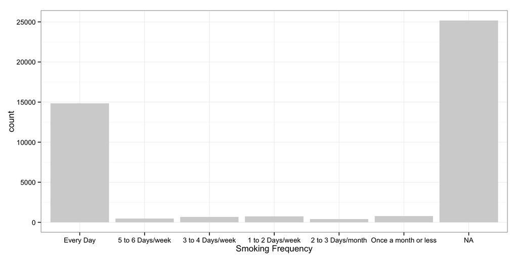

```r
library(ggplot2)
ggplot(data = NESARC, aes(x = S3AQ3B1)) +
  geom_bar(fill = "lightgray") +
  labs(x = "Smoking Frequency") +
  theme_bw()
```

If you do not want to see the `NA`’s use

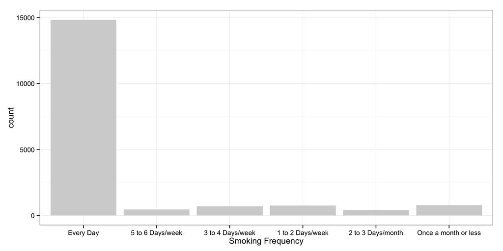

```r
ggplot(data = na.omit(NESARC[ , "S3AQ3B1", drop = FALSE]), aes(x = S3AQ3B1)) +
  geom_bar(fill = "lightgray") +
  labs(x = "Smoking Frequency") +
  theme_bw()
```

The variable `S4AQ4A1` represents unknown values with a 9, `No` values with a 2, and `Yes` values with a 1.

```r
summary(NESARC$S4AQ4A1)
```

```
    1     2     9  NA's
 4650  8712   391 29340
```

To recode the NA’s as `No` enter

```r
NESARCre <- NESARC
NESARCre$S4AQ4A1[is.na(NESARCre$S4AQ4A1)] <- 2
summary(NESARCre$S4AQ4A1)
```

```
    1     2     9
 4650 38052   391
```

```r
NESARCre$S4AQ4A1 <- factor(NESARCre$S4AQ4A1)
summary(NESARCre$S4AQ4A1)
```

```
    1     2     9
 4650 38052   391
```

```r
rm(NESARCre)  # remove NESARCre and newly created S4AQ4A1
```

### Collapsing Categories

Consider the variable `S1Q6A` with 14 levels recording the highest level of education of the participant. To collapse the categories in to dichotomous variable indicating the presence of a high school degree use the `ifelse` function. The levels `1`, `2`, `3`, `4`, `5`, `6`, and `7` of the variable `S1Q6A` correspond to education levels less than completing high school.

```r
NESARC$HS_DEGREE <- factor(ifelse(NESARC$S1Q6A %in% c("1", "2", "3", "4", "5", "6", "7"),
                                  "No", "Yes"))
summary(NESARC$HS_DEGREE)
```

```
   No   Yes
 7849 35244
```

### Creating a Factor from a Numeric Vector

To create a factor with three levels (young adults, adults, older adults) using the variable `AGE` (a numeric vector) use the function `cut`.

```r
NESARC$AGEfac <- cut(NESARC$AGE, breaks = c(18, 30, 50, Inf),
                     labels = c("Young Adult", "Adult", "Older Adult"),
                     include.lowest = TRUE)
summary(NESARC$AGEfac)
```

```
Young Adult       Adult Older Adult
       9535       17260       16298
```

Consider collapsing the numeric vector `S3AQ3C1` (usual quantity when cigarettes smoked) into a categorical variable with 5 levels.

```r
NESARC$S3AQ3C1fac <- cut(NESARC$S3AQ3C1, breaks = c(0, 5, 10, 15, 20, 100),
                         include.lowest = TRUE)
summary(NESARC$S3AQ3C1fac)
```

```
   [0,5]   (5,10]  (10,15]  (15,20] (20,100]     NA's
    4384     4157     1163     5492     2817    25080
```

### Aggregating Variables using `ifelse`

Consider creating a new variable `DepressLife` which is `Yes` if the variable `MAJORLIFE` is a 1 or if `DYSLIFE` is a 1.

```r
NESARC$DepressLife <- factor(ifelse( (NESARC$MAJORDEPLIFE == 1 | NESARC$DYSLIFE == 1),
                                     "Yes", "No"))
summary(NESARC$DepressLife)
```

```
   No   Yes
34894  8199
```

As another example, consider creating a variable `PPpanic` for past and present panic disorders. The variables `APANDX12` and `APANDXP12` record a panic disorder within the last 12 months and prior to the last 12 months with agoraphobia, respectively. The variables `PANDX12` and `PANDXP12` record a panic disorder within the last 12 months and prior to the last 12 months without agoraphobia, respectively.

```r
NESARC$PPpanic <- factor(ifelse( (NESARC$APANDX12 == 1 | NESARC$APANDXP12 == 1 |
                                    NESARC$PANDX12 == 1 | NESARC$PANDXP12 == 1 ),
                                 "Yes", "No"))
summary(NESARC$PPpanic)
```

```
   No   Yes
40799  2294
```

Consider a new variable `AllDeprSymp` that records whether a subject exhibits all depression symptoms or not. There are 19 depression symptoms recorded in the variables `S4AQ4A1` - `S4AQ4A19`. Note that the logical operator `&` is used to test if all depression symptoms are present.

```r
NESARC$AllDeprSymp <- factor(ifelse( (NESARC$S4AQ4A1 == 1 & NESARC$S4AQ4A2 == 1 &
                                        NESARC$S4AQ4A3 == 1 & NESARC$S4AQ4A4 == 1 &
                                        NESARC$S4AQ4A5 == 1 & NESARC$S4AQ4A6 == 1 &
                                        NESARC$S4AQ4A7 == 1 & NESARC$S4AQ4A8 == 1 &
                                        NESARC$S4AQ4A9 == 1 & NESARC$S4AQ4A10 == 1 &
                                        NESARC$S4AQ4A11 == 1 & NESARC$S4AQ4A12 == 1 &
                                        NESARC$S4AQ4A13 == 1 & NESARC$S4AQ4A14 == 1 &
                                        NESARC$S4AQ4A15 == 1 & NESARC$S4AQ4A16 == 1 &
                                        NESARC$S4AQ4A17 == 1 & NESARC$S4AQ4A18 == 1 &
                                        NESARC$S4AQ4A19 == 1), "Yes", "No"))
summary(NESARC$AllDeprSymp)
```

```
   No   Yes  NA's
13738    15 29340
```

### Creating a Composite Factor

The following code selects the 19 variables that deal with depression using the `selects` function from `dplyr`. Next, the values of the factors are converted to character strings; then, the character strings are converted to numeric values. The function `myfix` is constructed to convert values 2 and 9 to 0. The function `myfix` is applied to `sdf`, and the result is saved in the matrix `nsd`. The matrix `nsd` is converted to a data frame `nsd`, and the function `apply` is used to find the number of depression symptoms and store the result in the variable `NDS`.

```r
sdf <- NESARC %>%
  select(contains("S4AQ4A"))
sdf[] <- lapply(sdf, as.character)
sdf[] <- lapply(sdf, as.numeric)
myfix <- function(x){ifelse(x %in% c(2, 9), 0, ifelse(x == 1, 1, NA))}
nsd <- apply(sdf, 2, myfix)
nsd <- as.data.frame(nsd)
nsd$NDS <- apply(nsd, 1, sum, na.rm = FALSE)
xtabs(~NDS, data = nsd)
```

```
NDS
   0    1    2    3    4    5    6    7    8    9   10   11   12   13   14
1125  716  840  874  997 1032 1056 1043  970  981  940  824  737  586  413
  15   16   17   18   19
 295  181   97   31   15
```

Another approach:

```r
mysum <- function(x){sum(x == 1)}
myadd <- function(x){apply(x, 1, mysum)}
ndf <- NESARC %>%
  select(contains("S4AQ4A"))
nDS <- myadd(ndf)
ndf <- cbind(ndf, nDS)
xtabs(~nDS, data = ndf)
```

```
nDS
   0    1    2    3    4    5    6    7    8    9   10   11   12   13   14
1125  716  840  874  997 1032 1056 1043  970  981  940  824  737  586  413
  15   16   17   18   19
 295  181   97   31   15
```

#### Convert a factor to numeric

Be careful when converting a factor to a vector of numeric values based on the factor labels. One may be tempted to use `as.numeric` to convert a factor to a numeric vector. However, using `as.numeric(my_factor)` returns a numeric vector of the index levels not the actual values.

```r
summary(NESARC$S4AQ4A1)
```

```
    1     2     9  NA's
 4650  8712   391 29340
```

```r
levels(NESARC$S4AQ4A1)
```

```
[1] "1" "2" "9"
```

```r
table(as.numeric(NESARC$S4AQ4A1))
```

```
   1    2    3
4650 8712  391
```

To get the actual values of the factor use `as.numeric(levels(my_factor))[my_factor]`.

```r
summary(NESARC$S4AQ4A1)
```

```
    1     2     9  NA's
 4650  8712   391 29340
```

```r
levels(NESARC$S4AQ4A1)
```

```
[1] "1" "2" "9"
```

```r
table(as.numeric(levels(NESARC$S4AQ4A1))[NESARC$S4AQ4A1])
```

```
   1    2    9
4650 8712  391
```

To create a variable `NumDepSym` that records the number of depression symptoms among the variables `S4AQ4A1` - `S4AQ4A19`, create numeric variables from the factors `S4AQ4A1` - `S4AQ4A19` and store the results in `S4AQ4A1num` - `S4AQ4A19num`. Next, recode the levels of `No` (2) and `Unknown` (9) to 0s for variables `S4AQ4A1num` - `S4AQ4A19num`. The code is rather lengthy and other approaches such as the first two are encouraged. The template given in the PDS IBook link will not work with this data because the variables are factors not numeric vectors. You can not add factors!

```r
summary(NESARC$S4AQ4A1)
```

```
    1     2     9  NA's
 4650  8712   391 29340
```

```r
levels(NESARC$S4AQ4A1)
```

```
[1] "1" "2" "9"
```

```r
table(as.numeric(NESARC$S4AQ4A1))
```

```
   1    2    3
4650 8712  391
```

```r
NESARC$S4AQ4A1num <- as.numeric(levels(NESARC$S4AQ4A1))[NESARC$S4AQ4A1]
xtabs(~S4AQ4A1num, data = NESARC)
```

```
S4AQ4A1num
   1    2    9
4650 8712  391
```

```r
NESARC$S4AQ4A1num[NESARC$S4AQ4A1num == 2 | NESARC$S4AQ4A1num == 9] <- 0
xtabs(~S4AQ4A1num, data = NESARC)
```

```
S4AQ4A1num
   0    1
9103 4650
```

```r
NESARC$S4AQ4A2num <- as.numeric(levels(NESARC$S4AQ4A2))[NESARC$S4AQ4A2]
NESARC$S4AQ4A2num[NESARC$S4AQ4A2num == 2 | NESARC$S4AQ4A2num == 9] <- 0
NESARC$S4AQ4A3num <- as.numeric(levels(NESARC$S4AQ4A3))[NESARC$S4AQ4A3]
NESARC$S4AQ4A3num[NESARC$S4AQ4A3num == 2 | NESARC$S4AQ4A3num == 9] <- 0
NESARC$S4AQ4A4num <- as.numeric(levels(NESARC$S4AQ4A4))[NESARC$S4AQ4A4]
NESARC$S4AQ4A4num[NESARC$S4AQ4A4num == 2 | NESARC$S4AQ4A4num == 9] <- 0
NESARC$S4AQ4A5num <- as.numeric(levels(NESARC$S4AQ4A5))[NESARC$S4AQ4A5]
NESARC$S4AQ4A5num[NESARC$S4AQ4A5num == 2 | NESARC$S4AQ4A5num == 9] <- 0
NESARC$S4AQ4A6num <- as.numeric(levels(NESARC$S4AQ4A6))[NESARC$S4AQ4A6]
NESARC$S4AQ4A6num[NESARC$S4AQ4A6num == 2 | NESARC$S4AQ4A6num == 9] <- 0
NESARC$S4AQ4A7num <- as.numeric(levels(NESARC$S4AQ4A7))[NESARC$S4AQ4A7]
NESARC$S4AQ4A7num[NESARC$S4AQ4A7num == 2 | NESARC$S4AQ4A7num == 9] <- 0
NESARC$S4AQ4A8num <- as.numeric(levels(NESARC$S4AQ4A8))[NESARC$S4AQ4A8]
NESARC$S4AQ4A8num[NESARC$S4AQ4A8num == 2 | NESARC$S4AQ4A8num == 9] <- 0
NESARC$S4AQ4A9num <- as.numeric(levels(NESARC$S4AQ4A9))[NESARC$S4AQ4A9]
NESARC$S4AQ4A9num[NESARC$S4AQ4A9num == 2 | NESARC$S4AQ4A9num == 9] <- 0
NESARC$S4AQ4A10num <- as.numeric(levels(NESARC$S4AQ4A10))[NESARC$S4AQ4A10]
NESARC$S4AQ4A10num[NESARC$S4AQ4A10num == 2 | NESARC$S4AQ4A10num == 9] <- 0
NESARC$S4AQ4A11num <- as.numeric(levels(NESARC$S4AQ4A11))[NESARC$S4AQ4A11]
NESARC$S4AQ4A11num[NESARC$S4AQ4A11num == 2 | NESARC$S4AQ4A11num == 9] <- 0
NESARC$S4AQ4A12num <- as.numeric(levels(NESARC$S4AQ4A12))[NESARC$S4AQ4A12]
NESARC$S4AQ4A12num[NESARC$S4AQ4A12num == 2 | NESARC$S4AQ4A12num == 9] <- 0
NESARC$S4AQ4A13num <- as.numeric(levels(NESARC$S4AQ4A13))[NESARC$S4AQ4A13]
NESARC$S4AQ4A13num[NESARC$S4AQ4A13num == 2 | NESARC$S4AQ4A13num == 9] <- 0
NESARC$S4AQ4A14num <- as.numeric(levels(NESARC$S4AQ4A14))[NESARC$S4AQ4A14]
NESARC$S4AQ4A14num[NESARC$S4AQ4A14num == 2 | NESARC$S4AQ4A14num == 9] <- 0
NESARC$S4AQ4A15num <- as.numeric(levels(NESARC$S4AQ4A15))[NESARC$S4AQ4A15]
NESARC$S4AQ4A15num[NESARC$S4AQ4A15num == 2 | NESARC$S4AQ4A15num == 9] <- 0
NESARC$S4AQ4A16num <- as.numeric(levels(NESARC$S4AQ4A16))[NESARC$S4AQ4A16]
NESARC$S4AQ4A16num[NESARC$S4AQ4A16num == 2 | NESARC$S4AQ4A16num == 9] <- 0
NESARC$S4AQ4A17num <- as.numeric(levels(NESARC$S4AQ4A17))[NESARC$S4AQ4A17]
NESARC$S4AQ4A17num[NESARC$S4AQ4A17num == 2 | NESARC$S4AQ4A17num == 9] <- 0
NESARC$S4AQ4A18num <- as.numeric(levels(NESARC$S4AQ4A18))[NESARC$S4AQ4A18]
NESARC$S4AQ4A18num[NESARC$S4AQ4A18num == 2 | NESARC$S4AQ4A18num == 9] <- 0
NESARC$S4AQ4A19num <- as.numeric(levels(NESARC$S4AQ4A19))[NESARC$S4AQ4A19]
NESARC$S4AQ4A19num[NESARC$S4AQ4A19num == 2 | NESARC$S4AQ4A19num == 9] <- 0
NESARC$NumDepSym <- NESARC$S4AQ4A1num + NESARC$S4AQ4A2num + NESARC$S4AQ4A3num +
  NESARC$S4AQ4A4num + NESARC$S4AQ4A5num + NESARC$S4AQ4A6num + NESARC$S4AQ4A7num +
  NESARC$S4AQ4A8num + NESARC$S4AQ4A9num + NESARC$S4AQ4A10num + NESARC$S4AQ4A11num +
  NESARC$S4AQ4A12num + NESARC$S4AQ4A13num + NESARC$S4AQ4A14num + NESARC$S4AQ4A15num +
  NESARC$S4AQ4A16num + NESARC$S4AQ4A17num + NESARC$S4AQ4A18num + NESARC$S4AQ4A19num
xtabs(~NumDepSym, data = NESARC)
```

```
NumDepSym
   0    1    2    3    4    5    6    7    8    9   10   11   12   13   14
1125  716  840  874  997 1032 1056 1043  970  981  940  824  737  586  413
  15   16   17   18   19
 295  181   97   31   15
```

### Subsetting Your Data

Three different approaches to subsetting data will be given. The first approach is to use the `dplyr` function `filter`; the second approach is to use indices; and the third approach is to use the function `subset`. Consider creating a subset of the `NESARC` data set where a person indicates

1. He/she has smoked over 100 cigarettes (`S3AQ1A == 1`)
2. He/she has smoked in the past year (`CHECK321 == 1`)
3. He/she has typically smoked every day over the last year (`S3AQ3B1 == 1`)
4. He/she is less than or equal to 25 years old (`AGE <= 25`)

The first approach uses the `filter` function with the `%>%` function.

```r
NESARCsub1 <- NESARC %>%
  filter(S3AQ1A == 1 & CHECK321 == 1 & S3AQ3B1 == "Every Day" & AGE <= 25)
dim(NESARCsub1)
```

```
[1] 1320 3034
```

The second approach uses standard indexing.

```r
NESARCsub2 <- NESARC[NESARC$S3AQ1A == 1 & NESARC$CHECK321 == 1 &
                       NESARC$S3AQ3B1 == "Every Day" & NESARC$AGE <= 25  &
                       !is.na(NESARC$S3AQ1A == 1 & NESARC$CHECK321 == 1 &
                       NESARC$S3AQ3B1 == "Every Day" & NESARC$AGE <= 25), ]
dim(NESARCsub2)
```

```
[1] 1320 3034
```

The third approach uses the `subset` function.

```r
NESARCsub3 <- subset(NESARC, subset = S3AQ1A == 1 & CHECK321 == 1 &
                       S3AQ3B1 == "Every Day" & AGE <= 25)
dim(NESARCsub3)
```

```
[1] 1320 3034
```

### Graphing a Numeric Variable with `ggplot2`

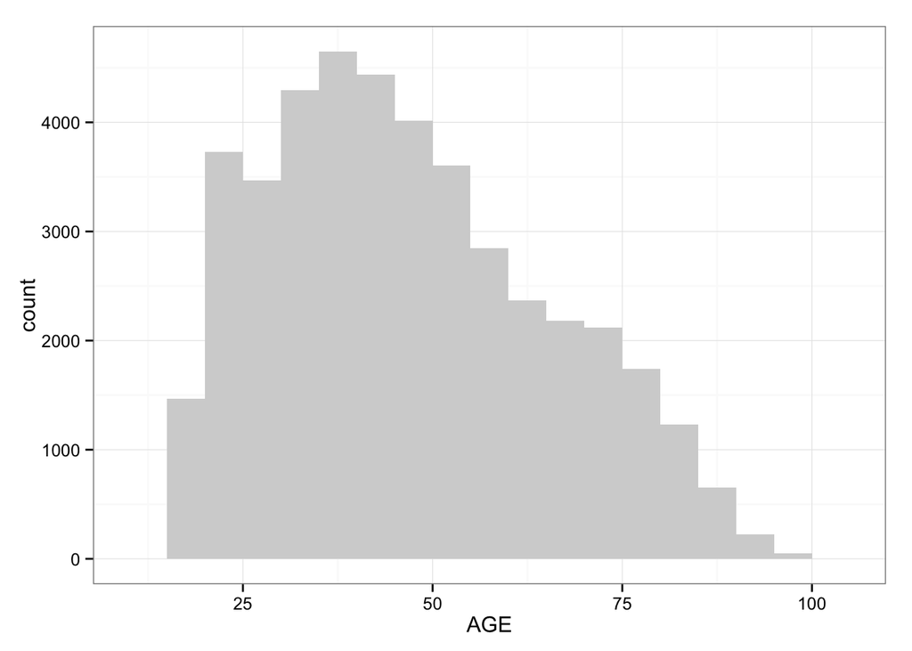

```r
ggplot(data = NESARC, aes(x = AGE)) +
  geom_histogram(binwidth = 5, fill = "lightgray") +
  theme_bw()
```

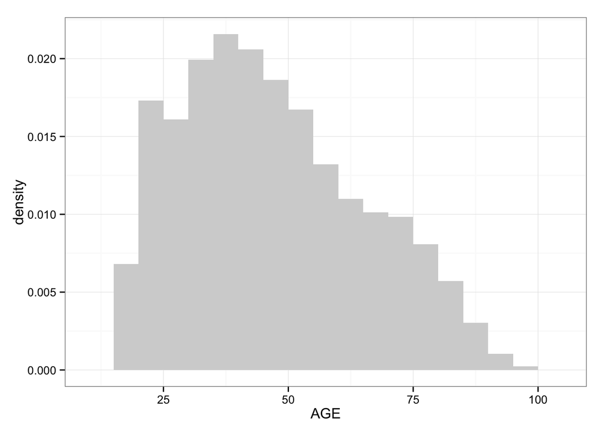

```r
ggplot(data = NESARC, aes(x = AGE, y = ..density..)) +
  geom_histogram(binwidth = 5, fill = "lightgray") +
  theme_bw()
```

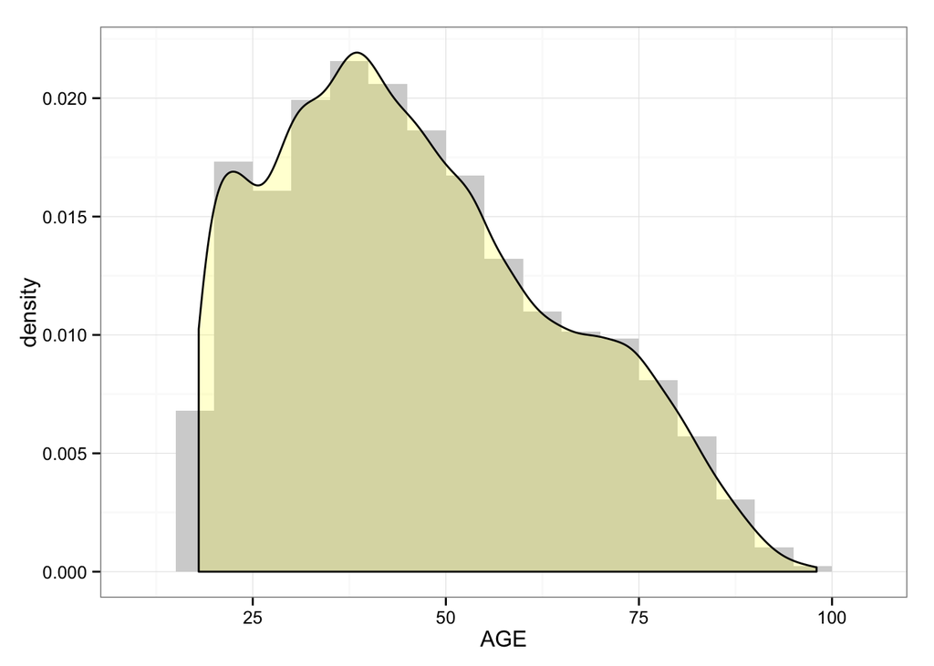

```r
ggplot(data = NESARC, aes(x = AGE, y = ..density..)) +
  geom_histogram(binwidth = 5, fill = "lightgray") +
  theme_bw() +
  geom_density(fill = "yellow", alpha = 0.2)
```

Creating a `MINI` data frame tbl.

```r
MINI <- NESARC %>%
  select(S1Q24FT, S1Q24IN, S1Q24LB, SEX) %>%
  filter(S1Q24FT < 99, S1Q24IN < 99, S1Q24LB < 999) %>%
  mutate(Inches = (S1Q24FT*12 + S1Q24IN),
         Sex = factor(SEX,  labels =c("Male", "Female"))) %>%
  rename(Weight = S1Q24LB)
MINI
```

```
Source: local data frame [41,654 x 6]

   S1Q24FT S1Q24IN Weight SEX Inches    Sex
1        5       7    195   1     67   Male
2        5       1    127   2     61 Female
3        5       4    185   2     64 Female
4        5       7    180   1     67   Male
5        6       1    220   1     73   Male
6        5       5    140   2     65 Female
7        5       9    160   1     69   Male
8        5       4    120   2     64 Female
9        5       4    140   2     64 Female
10       5      10    150   2     70 Female
..     ...     ...    ... ...    ...    ...
```

Some more `ggplot2` graphs.

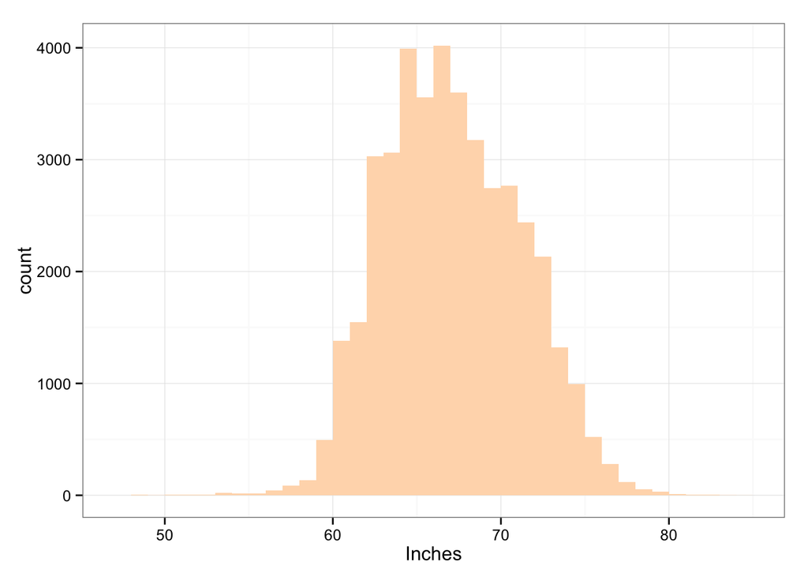

```r
ggplot(data = MINI, aes(x = Inches)) +
  geom_histogram(binwidth = 1, fill = "peachpuff") +
  theme_bw()
```

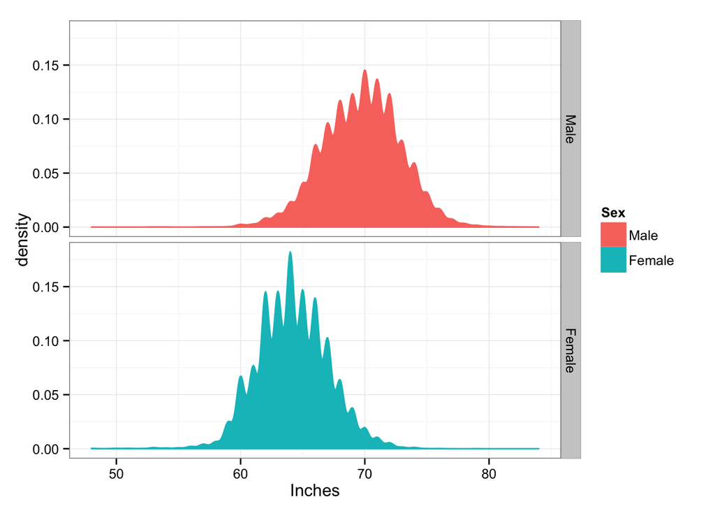

```r
ggplot(data = MINI, aes(x = Inches)) +
  geom_density(aes(fill = Sex, color = Sex)) +
  theme_bw() +
  facet_grid(Sex ~ .)
```

```r
tapply(MINI$Inches, MINI$Sex, median)
```

```
  Male Female
    70     64
```

### Some Bivariate Graphs with `ggplot2`

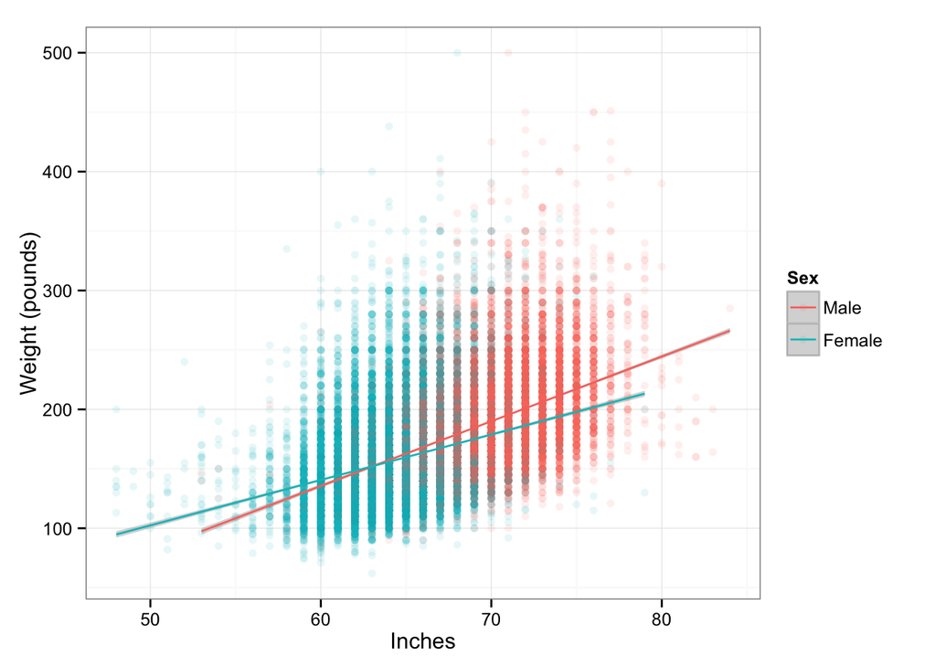

```r
ggplot(data = MINI, aes(x = Inches, y = Weight, color = Sex)) +
  geom_point(alpha = 0.1) +
  stat_smooth(method = "lm") +
  theme_bw() +
  labs(y = "Weight (pounds)")
```

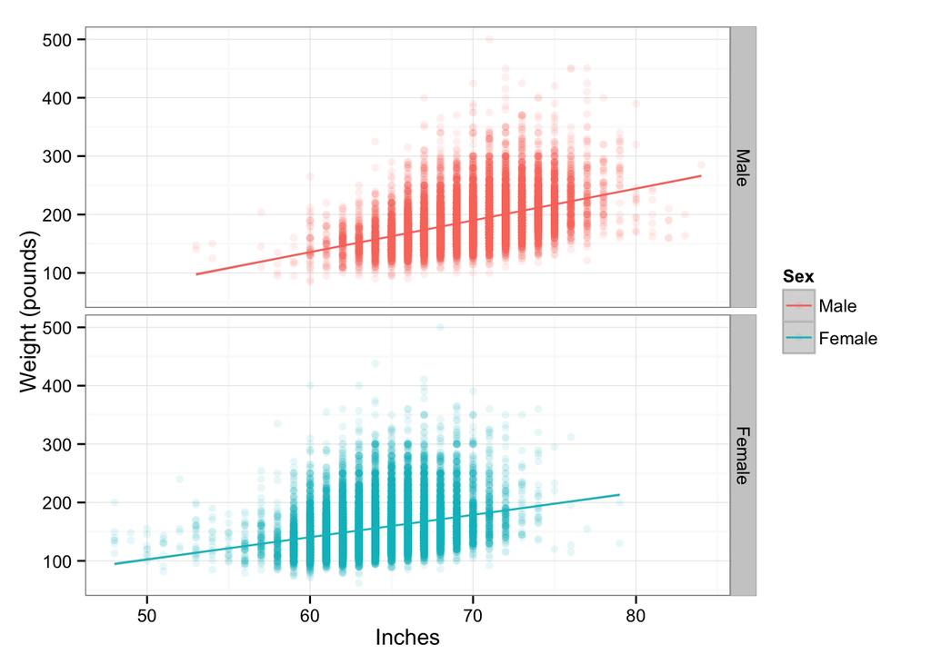

```r
ggplot(data = MINI, aes(x = Inches, y = Weight)) +
  geom_point(alpha = 0.1, aes(color = Sex)) +
  stat_smooth(method = "lm", aes(color = Sex)) +
  facet_grid(Sex ~ .) +
  theme_bw() +
  labs(y = "Weight (pounds)")
```

### ANOVA Example

```r
my.aov <- aov(S3AQ3C1 ~ TAB12MDX, data = subset(NESARC, S3AQ3C1 < 99)) # Note S3AQ3C1 == 99 is NA
summary(my.aov)
```

```
               Df  Sum Sq Mean Sq F value Pr(>F)
TAB12MDX        1   25308   25308   164.5 <2e-16 ***
Residuals   17749 2731241     154
---
Signif. codes:  0 '***' 0.001 '**' 0.01 '*' 0.05 '.' 0.1 ' ' 1
```

```r
TukeyHSD(my.aov)
```

```
  Tukey multiple comparisons of means
    95% family-wise confidence level

Fit: aov(formula = S3AQ3C1 ~ TAB12MDX, data = subset(NESARC, S3AQ3C1 < 99))

$TAB12MDX
        diff      lwr      upr p adj
1-0 2.690191 2.279019 3.101364     0
```

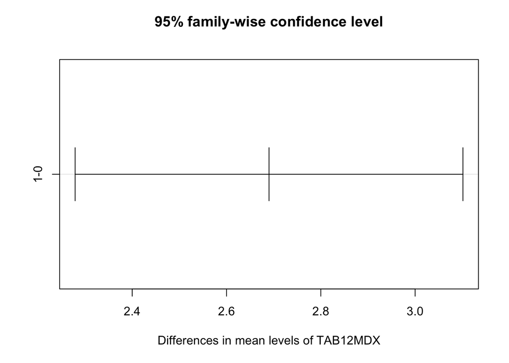

```r
plot(TukeyHSD(my.aov))
```

A plot of the residuals indicates problems with this model.

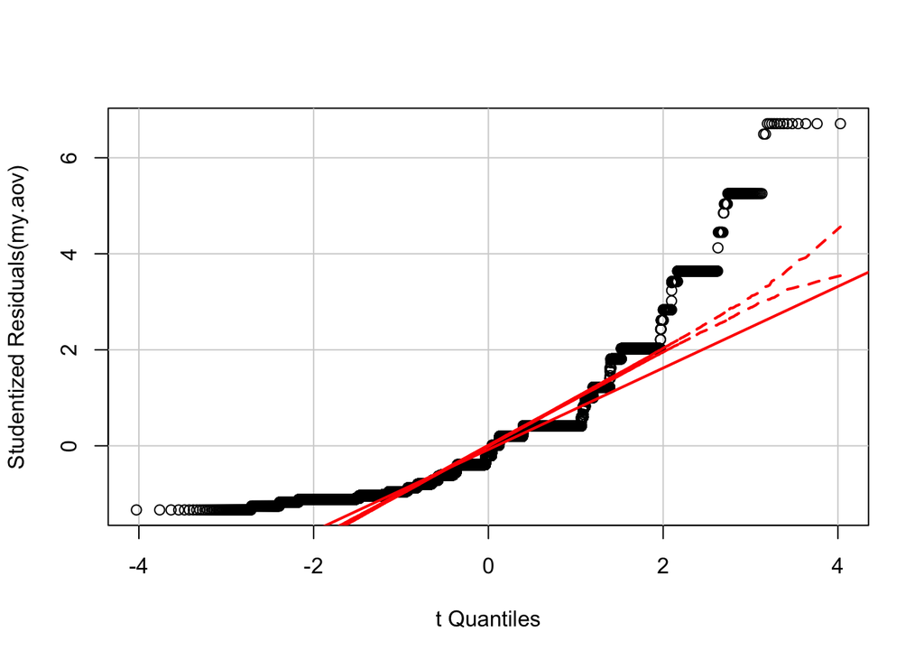

```r
library(car)
qqPlot(my.aov)
```

### Regression Example

```r
my.lm <- lm(Weight ~ Inches, data = MINI)
summary(my.lm)
```

```
Call:
lm(formula = Weight ~ Inches, data = MINI)

Residuals:
    Min      1Q  Median      3Q     Max
-104.17  -23.90   -6.87   17.72  322.32

Coefficients:
             Estimate Std. Error t value Pr(>|t|)
(Intercept) -171.5037     2.8834  -59.48   <2e-16 ***
Inches         5.1351     0.0432  118.87   <2e-16 ***
---
Signif. codes:  0 '***' 0.001 '**' 0.01 '*' 0.05 '.' 0.1 ' ' 1

Residual standard error: 35.73 on 41652 degrees of freedom
Multiple R-squared:  0.2533,    Adjusted R-squared:  0.2533
F-statistic: 1.413e+04 on 1 and 41652 DF,  p-value: < 2.2e-16
```

```r
confint(my.lm)  # Do not use this until you know your model is appropriate
```

```
                  2.5 %      97.5 %
(Intercept) -177.155249 -165.852111
Inches         5.050445    5.219782
```

```r
my.lm2 <- lm(Weight ~ Inches + Sex + Inches:Sex, data = MINI)
summary(my.lm2)
```

```
Call:
lm(formula = Weight ~ Inches + Sex + Inches:Sex, data = MINI)

Residuals:
    Min      1Q  Median      3Q     Max
-107.09  -24.73   -5.91   17.79  328.81

Coefficients:
                   Estimate Std. Error t value Pr(>|t|)
(Intercept)      -191.02282    5.88528  -32.46   <2e-16 ***
Inches              5.44308    0.08429   64.57   <2e-16 ***
SexFemale         102.40420    7.86671   13.02   <2e-16 ***
Inches:SexFemale   -1.62239    0.11705  -13.86   <2e-16 ***
---
Signif. codes:  0 '***' 0.001 '**' 0.01 '*' 0.05 '.' 0.1 ' ' 1

Residual standard error: 35.57 on 41650 degrees of freedom
Multiple R-squared:   0.26, Adjusted R-squared:  0.2599
F-statistic:  4877 on 3 and 41650 DF,  p-value: < 2.2e-16
```

Plots of the residuals indicate problems with both `my.lm` and `my.lm2`.

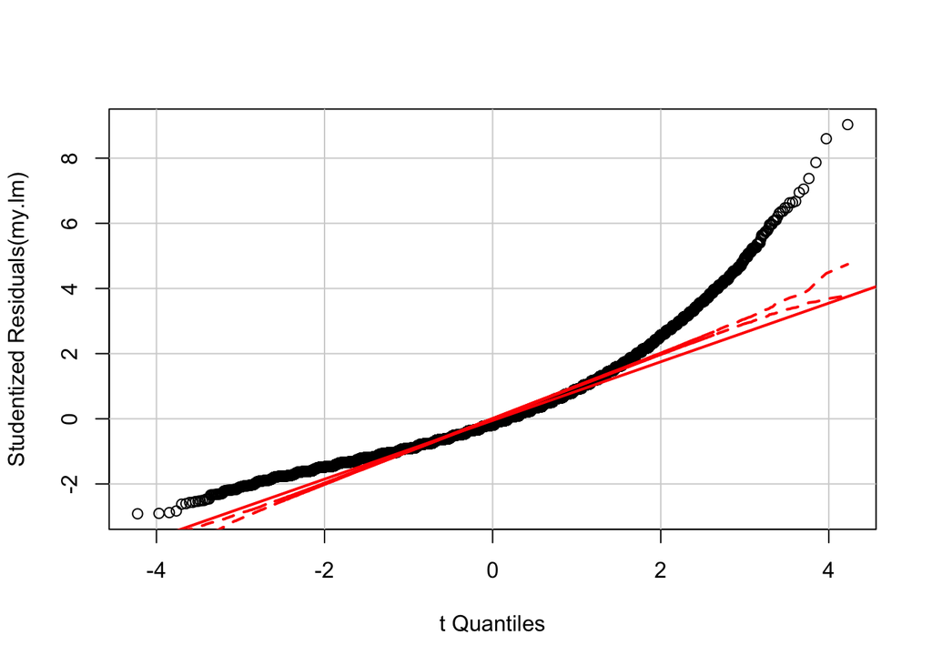

```r
qqPlot(my.lm)
```

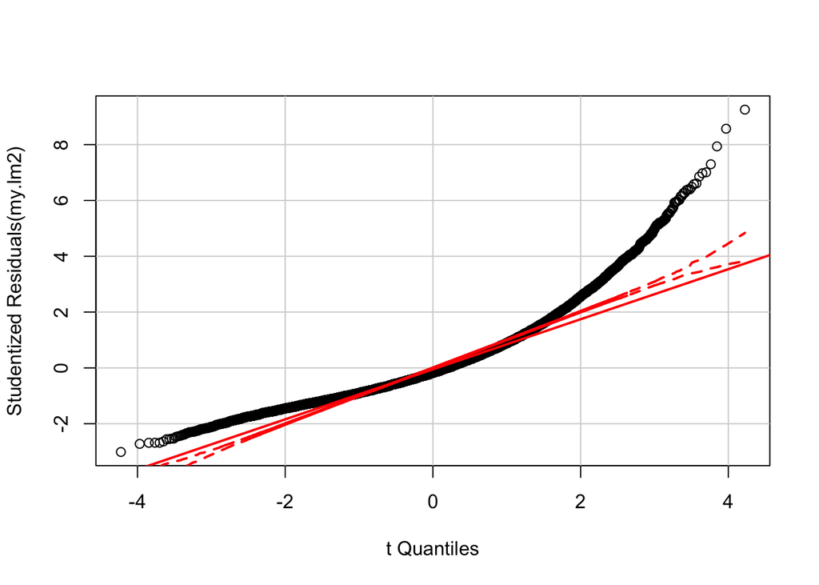

```r
qqPlot(my.lm2)
```

### Displaying a Table

First, the code and output is shown for a table. Then the `xtable` function from the `xtable` package is used to create and display the table in the document.

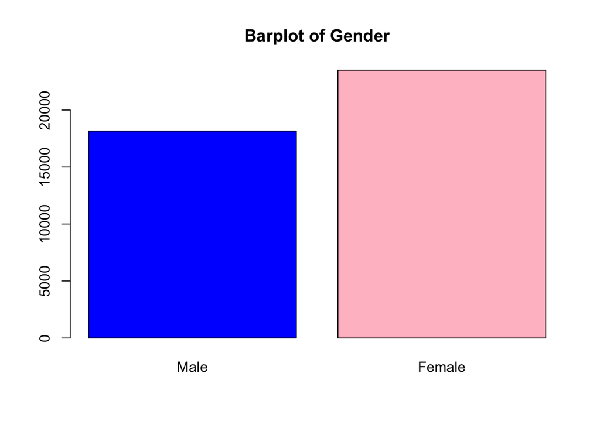

```
ordered(MINI$Sex)
       Frequency Percent Cum Percent
Male       18159   43.59       43.59
Female     23495   56.41      100.00
Total      41654  100.00
```

```r
library(descr)
freq(ordered(MINI$Sex), plot = TRUE, col = c("blue","pink"), main = "Barplot of Gender")
```

```r
library(xtable) # Must be loaded to call xtable
T1 <- xtable(freq(ordered(MINI$Sex), plot = FALSE),
             caption = "Table 1: Frequency Table of `Sex`")
print(T1, type = "html", caption.placement = "top", html.table.attributes = 1,
      timestamp = NULL)
```

Table 1: Frequency Table of `Sex`

|  | Frequency | Percent | Cum Percent |
| --- | --- | --- | --- |
| Male | 18159 | 43.59 | 43.59 |
| Female | 23495 | 56.41 | 100.00 |
| Total | 41654 | 100.00 |  |

```r
library(knitr)
kable(freq(ordered(MINI$Sex), plot = FALSE), format = "markdown",
      digits = 2, padding = 0)
```

|  | Frequency | Percent | Cum Percent |
| --- | --- | --- | --- |
| Male | 18159 | 43.59 | 43.59 |
| Female | 23495 | 56.41 | 100.00 |
| Total | 41654 | 100.00 | NA |

```r
library(knitr)
kable(freq(ordered(MINI$Sex), plot = FALSE), format = "html", digits = 2,
      caption = "Table 2: Frequency Table of `Sex`")
```

Table 2: Frequency Table of `Sex`

|  | Frequency | Percent | Cum Percent |
| --- | --- | --- | --- |
| Male | 18159 | 43.59 | 43.59 |
| Female | 23495 | 56.41 | 100.00 |
| Total | 41654 | 100.00 | NA |

This work is licensed under the [CC BY-NC 3.0 Creative Commons License](http://creativecommons.org/licenses/by-nc/3.0/).